# Trabajo Final - Programación para la Ciencia de Datos

Javier Callejas Cardozo & Xiomara Grisales Henao

## Instalación de paquetes

Se realiza la instalación de paquetes, pero debido a que previamente se instalaron, procedimos a dejarlos como comentarios

```python
# Intalación de paquetes requeridos

#pip install pandas
#pip install seaborn
#pip install matplotlib
```

## Importación de librerías

```python
# Importación de librerías necesarias para uso en el trabajo final

import numpy as np
import pandas as pd
import re
import os
import matplotlib
import matplotlib.pyplot as plt
import seaborn as sns
```

## Carga de las Bases de Datos

Carga de bases de datos seleccionadas por el equipo de trabajo (Bases de Datos Alcohol en estudiantes)

```python
# Carga del Data Frame #1 - Estudiantes de la clase de Portugués
df_student_por = pd.read_csv("student-por.csv")

# Carga del Data Frame #2 - Estudiantes de la clase de Matemáticas
df_studen_mat = pd.read_csv("student-mat.csv")
```

## Análisis exploratorio de las variables por Data Frame

Se verifica el tipo de datos de los Data Frame

```python
# Verificación de los tipos de datos del Data Frame #1 - Estudiantes de la clase de Portugués
df_student_por.dtypes
```

```
school        object
sex           object
age            int64
address       object
famsize       object
Pstatus       object
Medu           int64
Fedu           int64
Mjob          object
Fjob          object
reason        object
guardian      object
traveltime     int64
studytime      int64
failures       int64
schoolsup     object
famsup        object
paid          object
activities    object
nursery       object
higher        object
internet      object
romantic      object
famrel         int64
freetime       int64
goout          int64
Dalc           int64
Walc           int64
health         int64
absences       int64
G1             int64
G2             int64
G3             int64
dtype: object
```

```python
# Verificación de los tipos de datos del Data Frame #2 - Estudiantes de la clase de Matemáticas
df_studen_mat.dtypes
```

```
school        object
sex           object
age            int64
address       object
famsize       object
Pstatus       object
Medu           int64
Fedu           int64
Mjob          object
Fjob          object
reason        object
guardian      object
traveltime     int64
studytime      int64
failures       int64
schoolsup     object
famsup        object
paid          object
activities    object
nursery       object
higher        object
internet      object
romantic      object
famrel         int64
freetime       int64
goout          int64
Dalc           int64
Walc           int64
health         int64
absences       int64
G1             int64
G2             int64
G3             int64
dtype: object
```

Analizando las bases de datos, no se encontró una columna diferenciadora por asignaturas, se decidió crear una nueva columna para cada una definiéndolas

```python
# Creación de la columna en el Data Frame #1 'asignature' definiendo como 'por' los estudiantes que cursaron la asignatura portugués
df_student_por["asignature"] = "por"

# Visualización de la base de datos con la nueva columna
df_student_por.head(3)
```

|  | school | sex | age | address | famsize | Pstatus | Medu | Fedu | Mjob | Fjob | ... | freetime | goout | Dalc | Walc | health | absences | G1 | G2 | G3 | asignature |
| --- | --- | --- | --- | --- | --- | --- | --- | --- | --- | --- | --- | --- | --- | --- | --- | --- | --- | --- | --- | --- | --- |
| 0 | GP | F | 18 | U | GT3 | A | 4 | 4 | at_home | teacher | ... | 3 | 4 | 1 | 1 | 3 | 4 | 0 | 11 | 11 | por |
| 1 | GP | F | 17 | U | GT3 | T | 1 | 1 | at_home | other | ... | 3 | 3 | 1 | 1 | 3 | 2 | 9 | 11 | 11 | por |
| 2 | GP | F | 15 | U | LE3 | T | 1 | 1 | at_home | other | ... | 3 | 2 | 2 | 3 | 3 | 6 | 12 | 13 | 12 | por |

3 rows × 34 columns

```python
# Creación de la columna en el Data Frame #1 'asignature' definiendo como 'mat' los estudiantes que cursaron la asignatura matemáticas
df_studen_mat["asignature"] = "mat"

# Visualización de la base de datos con la nueva columna
df_studen_mat.head(3)
```

|  | school | sex | age | address | famsize | Pstatus | Medu | Fedu | Mjob | Fjob | ... | freetime | goout | Dalc | Walc | health | absences | G1 | G2 | G3 | asignature |
| --- | --- | --- | --- | --- | --- | --- | --- | --- | --- | --- | --- | --- | --- | --- | --- | --- | --- | --- | --- | --- | --- |
| 0 | GP | F | 18 | U | GT3 | A | 4 | 4 | at_home | teacher | ... | 3 | 4 | 1 | 1 | 3 | 6 | 5 | 6 | 6 | mat |
| 1 | GP | F | 17 | U | GT3 | T | 1 | 1 | at_home | other | ... | 3 | 3 | 1 | 1 | 3 | 4 | 5 | 5 | 6 | mat |
| 2 | GP | F | 15 | U | LE3 | T | 1 | 1 | at_home | other | ... | 3 | 2 | 2 | 3 | 3 | 10 | 7 | 8 | 10 | mat |

3 rows × 34 columns

## Cruce de las Bases de Datos

Se procede a verificar las columnas, para aplicar concat o join

```python
# Verificación de las columnas del Data Frame #1 - Estudiantes de la clase de Portugués
df_student_por.columns
```

```
Index(['school', 'sex', 'age', 'address', 'famsize', 'Pstatus', 'Medu', 'Fedu',
       'Mjob', 'Fjob', 'reason', 'guardian', 'traveltime', 'studytime',
       'failures', 'schoolsup', 'famsup', 'paid', 'activities', 'nursery',
       'higher', 'internet', 'romantic', 'famrel', 'freetime', 'goout', 'Dalc',
       'Walc', 'health', 'absences', 'G1', 'G2', 'G3', 'asignature'],
      dtype='object')
```

```python
# Verificación de las columnas del Data Frame #2 - Estudiantes de la clase de Matemáticas
df_studen_mat.columns
```

```
Index(['school', 'sex', 'age', 'address', 'famsize', 'Pstatus', 'Medu', 'Fedu',
       'Mjob', 'Fjob', 'reason', 'guardian', 'traveltime', 'studytime',
       'failures', 'schoolsup', 'famsup', 'paid', 'activities', 'nursery',
       'higher', 'internet', 'romantic', 'famrel', 'freetime', 'goout', 'Dalc',
       'Walc', 'health', 'absences', 'G1', 'G2', 'G3', 'asignature'],
      dtype='object')
```

Se ejecuta la función concat para unir los bases de datos ya que tienen columnas con el mismo nombre e igual tipo de datos

```python
# Concatenación de las bases de datos
df_studen_consolidado = pd.concat([df_student_por,df_studen_mat], axis=0)
# Se deja axis en cero para que apile uno sobre el otro, ya que tienen las mismas columnas
```

Se visualizan los datos del nuevo data frame

```python
# Impresión de las primeras 5 filas de la Base de Datos concatenada
df_studen_consolidado.head(5)
```

|  | school | sex | age | address | famsize | Pstatus | Medu | Fedu | Mjob | Fjob | ... | freetime | goout | Dalc | Walc | health | absences | G1 | G2 | G3 | asignature |
| --- | --- | --- | --- | --- | --- | --- | --- | --- | --- | --- | --- | --- | --- | --- | --- | --- | --- | --- | --- | --- | --- |
| 0 | GP | F | 18 | U | GT3 | A | 4 | 4 | at_home | teacher | ... | 3 | 4 | 1 | 1 | 3 | 4 | 0 | 11 | 11 | por |
| 1 | GP | F | 17 | U | GT3 | T | 1 | 1 | at_home | other | ... | 3 | 3 | 1 | 1 | 3 | 2 | 9 | 11 | 11 | por |
| 2 | GP | F | 15 | U | LE3 | T | 1 | 1 | at_home | other | ... | 3 | 2 | 2 | 3 | 3 | 6 | 12 | 13 | 12 | por |
| 3 | GP | F | 15 | U | GT3 | T | 4 | 2 | health | services | ... | 2 | 2 | 1 | 1 | 5 | 0 | 14 | 14 | 14 | por |
| 4 | GP | F | 16 | U | GT3 | T | 3 | 3 | other | other | ... | 3 | 2 | 1 | 2 | 5 | 0 | 11 | 13 | 13 | por |

5 rows × 34 columns

## Análisis exploratorio de datos (EDA)

### Análisis de tipos de variables

```python
# Revisión de los tipos de datos de la Base de Datos concatenada
df_studen_consolidado.dtypes
```

```
school        object
sex           object
age            int64
address       object
famsize       object
Pstatus       object
Medu           int64
Fedu           int64
Mjob          object
Fjob          object
reason        object
guardian      object
traveltime     int64
studytime      int64
failures       int64
schoolsup     object
famsup        object
paid          object
activities    object
nursery       object
higher        object
internet      object
romantic      object
famrel         int64
freetime       int64
goout          int64
Dalc           int64
Walc           int64
health         int64
absences       int64
G1             int64
G2             int64
G3             int64
asignature    object
dtype: object
```

### Limpieza de la Base de Datos

Limpieza de variables tipo string

```python
# Función de limpieza para las columnas de texto texto
def limpieza_texto(df, n_columna):
    df[n_columna] = df[n_columna].str.lower()                           # Convierte a minúsculas
    df[n_columna] = df[n_columna].str.strip()                           # Elimina espacios al inicio y al final de la cadena
    df[n_columna] = df[n_columna].str.replace('  ',' ')                 # Reemplaza dobles espacios por uno solo
    df[n_columna] = df[n_columna].str.replace(r'[^\w\s]','', regex=True) # Elimina caracteres que no sean alfanuméricos o caracteres especiales.
    #df[n_columna] = df[n_columna].str.replace('\d','', regex=True)     # Elimina números de la cadena
    return df

# Ciclo for para recorrer el date frame y aplicarle a todas las columnas de string la limpieza.
for j in df_studen_consolidado.columns:
    if df_studen_consolidado[j].dtype == 'object': # Se filtra solo por los tipo object para aplicarle la limpieza.
        limpieza_texto(df_studen_consolidado,j)
```

### Valores nulos

```python
nulos_por_columna = df_studen_consolidado.isnull().sum()
# Mostrar solo las columnas que tienen valores nulos
columnas_con_nulos = nulos_por_columna[nulos_por_columna > 0]
print(columnas_con_nulos)
#Finalmente no encontramos valores nulos
```

```
Series([], dtype: int64)
```

### Valores duplicados

```python
#Análisis de filas duplicadas en la DB, calculamos las filas antes de eliminar las repetidas
print(f'Tamaño del set antes de eliminar las filas repetidas: {df_studen_consolidado.shape}')

#Eliminamos filas duplicadas de la DB
df_studen_consolidado_1 = df_studen_consolidado.drop_duplicates()
#Impresión del tamaño del set luego de eliminar las duplicadas

print(f'Tamaño del set después de eliminar las filas repetidas: {df_studen_consolidado.shape}')
#Se evidencia que no se encuentran valores duplicados
```

```
Tamaño del set antes de eliminar las filas repetidas: (1044, 34)
Tamaño del set después de eliminar las filas repetidas: (1044, 34)
```

### Análisis de datos por columna

```python
#Recorremos los valores por columnas de nuestra base de datos y analizamos posibles datos a limpiar
for columns in df_studen_consolidado_1:
    print('Estos son los valores para', df_studen_consolidado_1[columns].value_counts(), sep="\n")
```

```
Estos son los valores para
school
gp    772
ms    272
Name: count, dtype: int64
Estos son los valores para
sex
f    591
m    453
Name: count, dtype: int64
Estos son los valores para
age
16    281
17    277
18    222
15    194
19     56
20      9
21      3
22      2
Name: count, dtype: int64
Estos son los valores para
address
u    759
r    285
Name: count, dtype: int64
Estos son los valores para
famsize
gt3    738
le3    306
Name: count, dtype: int64
Estos son los valores para
Pstatus
t    923
a    121
Name: count, dtype: int64
Estos son los valores para
Medu
4    306
2    289
```

[output cut: 241 more lines]

```
17     35
18     27
7      19
6      18
5       8
19      7
1       1
20      1
4       1
Name: count, dtype: int64
Estos son los valores para
asignature
por    649
mat    395
Name: count, dtype: int64
```

### Valores únicos

```python
# Revisamos valores únicos por columna analizando caracteres potenciales a limpiar
for col in df_studen_consolidado_1.columns:
  print('Estos son los valores únicos para', col.upper(),
        df_studen_consolidado_1[col].unique(), sep="\n")
```

```
Estos son los valores únicos para
SCHOOL
['gp' 'ms']
Estos son los valores únicos para
SEX
['f' 'm']
Estos son los valores únicos para
AGE
[18 17 15 16 19 22 20 21]
Estos son los valores únicos para
ADDRESS
['u' 'r']
Estos son los valores únicos para
FAMSIZE
['gt3' 'le3']
Estos son los valores únicos para
PSTATUS
['a' 't']
Estos son los valores únicos para
MEDU
[4 1 3 2 0]
Estos son los valores únicos para
FEDU
[4 1 2 3 0]
Estos son los valores únicos para
MJOB
['at_home' 'health' 'other' 'services' 'teacher']
Estos son los valores únicos para
FJOB
['teacher' 'other' 'services' 'health' 'at_home']
Estos son los valores únicos para
REASON
['course' 'other' 'home' 'reputation']
Estos son los valores únicos para
GUARDIAN
['mother' 'father' 'other']
Estos son los valores únicos para
TRAVELTIME
[2 1 3 4]
Estos son los valores únicos para
```

[output cut: 48 more lines]

```
ABSENCES
[ 4  2  6  0 10  8 16 14  1 12 24 22 32 30 21 15  9 18 26  7 11  5 13  3
 25 54 20 56 28 75 19 38 40 23 17]
Estos son los valores únicos para
G1
[ 0  9 12 14 11 13 10 15 17  8 16 18  7  6  5  4 19  3]
Estos son los valores únicos para
G2
[11 13 14 12 16 17  8 10 15  9  7  6 18 19  0  5  4]
Estos son los valores únicos para
G3
[11 12 14 13 17 15  7 10 16  9  8 18  6  0  1  5 19 20  4]
Estos son los valores únicos para
ASIGNATURE
['por' 'mat']
```

Revisón del tipo de valores por columna, con el fin de definir algún cambio de variable

```python
# Impresión de los tipos de datos por columna
df_studen_consolidado_1.dtypes

# Luego de un análisis exhaustivo por variables y su significado en el data frame
# Se decide no cambiar ningún tipo de variable ya que todas son acordes de acuerdo a los datos.
```

```
school        object
sex           object
age            int64
address       object
famsize       object
Pstatus       object
Medu           int64
Fedu           int64
Mjob          object
Fjob          object
reason        object
guardian      object
traveltime     int64
studytime      int64
failures       int64
schoolsup     object
famsup        object
paid          object
activities    object
nursery       object
higher        object
internet      object
romantic      object
famrel         int64
freetime       int64
goout          int64
Dalc           int64
Walc           int64
health         int64
absences       int64
G1             int64
G2             int64
G3             int64
asignature    object
dtype: object
```

## Filtro de la Base de Datos

#### Estudiantes con apoyo familiar y nota final mayor a 15

```python
# Filtrar por estudiantes con apoyo familiar que tienen calificaciones mayores a 15 en G3 que es la calificacion final
df_apoyo_familiar_altas_calificaciones = df_studen_consolidado_1[(df_studen_consolidado_1['famsup'] == 'yes') & (df_studen_consolidado_1['G3'] > 15)]
cantidad_filas_af = df_apoyo_familiar_altas_calificaciones.shape[0]
print(f"Estudiantes con apoyo familiar y nota final mayor a 15: {cantidad_filas_af}")

df_apoyo_familiar_altas_calificaciones.head()
```

```
Estudiantes con apoyo familiar y nota final mayor a 15: 77
```

|  | school | sex | age | address | famsize | Pstatus | Medu | Fedu | Mjob | Fjob | ... | freetime | goout | Dalc | Walc | health | absences | G1 | G2 | G3 | asignature |
| --- | --- | --- | --- | --- | --- | --- | --- | --- | --- | --- | --- | --- | --- | --- | --- | --- | --- | --- | --- | --- | --- |
| 8 | gp | m | 15 | u | le3 | a | 3 | 2 | services | other | ... | 2 | 2 | 1 | 1 | 1 | 0 | 15 | 16 | 17 | por |
| 15 | gp | f | 16 | u | gt3 | t | 4 | 4 | health | other | ... | 4 | 4 | 1 | 2 | 2 | 6 | 17 | 17 | 17 | por |
| 51 | gp | f | 15 | u | le3 | t | 4 | 2 | health | other | ... | 3 | 3 | 1 | 1 | 5 | 0 | 16 | 14 | 16 | por |
| 57 | gp | m | 15 | u | gt3 | t | 4 | 4 | teacher | health | ... | 2 | 2 | 1 | 1 | 5 | 8 | 15 | 15 | 16 | por |
| 59 | gp | f | 16 | u | gt3 | t | 4 | 2 | services | other | ... | 2 | 3 | 1 | 1 | 5 | 2 | 16 | 15 | 16 | por |

5 rows × 34 columns

Conclusión : Teniendo en cuenta ambas asignaturas, solo el 7% de los estudiantes, aprobaron las asignaturas y tuvieron apoyo familiar

#### Estudiantes con apoyo familiar y nota final mayor a 15 para la asignatura portugués

```python
# Filtrar por estudiantes con apoyo familiar que tienen calificaciones mayores a 15 en G3 que es la calificacion final en portugués
df_apoyo_familiar_altas_calificaciones_por = df_studen_consolidado_1[(df_studen_consolidado_1['famsup'] == 'yes') & (df_studen_consolidado_1['G3'] > 15)
                                                                      & (df_studen_consolidado_1['asignature']== 'por')]
cantidad_filas_af_por = df_apoyo_familiar_altas_calificaciones_por.shape[0]
print(f"Estudiantes con apoyo familiar y nota final mayor a 15 para la asignatura portugués: {cantidad_filas_af_por}")

df_apoyo_familiar_altas_calificaciones_por.head()
```

```
Estudiantes con apoyo familiar y nota final mayor a 15 para la asignatura portugués: 53
```

|  | school | sex | age | address | famsize | Pstatus | Medu | Fedu | Mjob | Fjob | ... | freetime | goout | Dalc | Walc | health | absences | G1 | G2 | G3 | asignature |
| --- | --- | --- | --- | --- | --- | --- | --- | --- | --- | --- | --- | --- | --- | --- | --- | --- | --- | --- | --- | --- | --- |
| 8 | gp | m | 15 | u | le3 | a | 3 | 2 | services | other | ... | 2 | 2 | 1 | 1 | 1 | 0 | 15 | 16 | 17 | por |
| 15 | gp | f | 16 | u | gt3 | t | 4 | 4 | health | other | ... | 4 | 4 | 1 | 2 | 2 | 6 | 17 | 17 | 17 | por |
| 51 | gp | f | 15 | u | le3 | t | 4 | 2 | health | other | ... | 3 | 3 | 1 | 1 | 5 | 0 | 16 | 14 | 16 | por |
| 57 | gp | m | 15 | u | gt3 | t | 4 | 4 | teacher | health | ... | 2 | 2 | 1 | 1 | 5 | 8 | 15 | 15 | 16 | por |
| 59 | gp | f | 16 | u | gt3 | t | 4 | 2 | services | other | ... | 2 | 3 | 1 | 1 | 5 | 2 | 16 | 15 | 16 | por |

5 rows × 34 columns

#### Estudiantes con apoyo familiar y nota final mayor a 15 para la asignatura matemáticas

```python
# Filtrar por estudiantes con apoyo familiar que tienen calificaciones mayores a 15 en G3 que es la calificacion final para matemáticas
df_apoyo_familiar_altas_calificaciones_mat = df_studen_consolidado_1[(df_studen_consolidado_1['famsup'] == 'yes') & (df_studen_consolidado_1['G3'] > 15)
                                                                 & (df_studen_consolidado_1['asignature']== 'mat')]
cantidad_filas_af_mat = df_apoyo_familiar_altas_calificaciones_mat.shape[0]
print(f"Estudiantes con apoyo familiar y nota final mayor a 15 para la asignatura matemáticas: {cantidad_filas_af_mat}")

df_apoyo_familiar_altas_calificaciones_mat.head()
```

```
Estudiantes con apoyo familiar y nota final mayor a 15 para la asignatura matemáticas: 24
```

|  | school | sex | age | address | famsize | Pstatus | Medu | Fedu | Mjob | Fjob | ... | freetime | goout | Dalc | Walc | health | absences | G1 | G2 | G3 | asignature |
| --- | --- | --- | --- | --- | --- | --- | --- | --- | --- | --- | --- | --- | --- | --- | --- | --- | --- | --- | --- | --- | --- |
| 8 | gp | m | 15 | u | le3 | a | 3 | 2 | services | other | ... | 2 | 2 | 1 | 1 | 1 | 0 | 16 | 18 | 19 | mat |
| 14 | gp | m | 15 | u | gt3 | a | 2 | 2 | other | other | ... | 5 | 2 | 1 | 1 | 3 | 0 | 14 | 16 | 16 | mat |
| 31 | gp | m | 15 | u | gt3 | t | 4 | 4 | services | services | ... | 3 | 1 | 1 | 1 | 5 | 0 | 17 | 16 | 17 | mat |
| 32 | gp | m | 15 | r | gt3 | t | 4 | 3 | teacher | at_home | ... | 5 | 2 | 1 | 1 | 5 | 0 | 17 | 16 | 16 | mat |
| 36 | gp | m | 15 | u | le3 | t | 4 | 3 | teacher | services | ... | 4 | 3 | 1 | 1 | 4 | 2 | 15 | 16 | 18 | mat |

5 rows × 34 columns

Conclusión : Teniendo en cuenta los estudiantes del curso matemáticas, solo el 6% de los estudiantes, aprobaron, y tuvieron apoyo familiar (Fueron menos)

#### Estudiantes con alto rendimiento académico, bajo consumo de alcohol, con apoyo familiar y mucho tiempo de estudio

```python
# Filtrar por estudiantes con alto rendimiento académico, bajo consumo de alcohol, apoyo familiar y mucho tiempo de estudio
df_altas_calificaciones_bajo_consumo_apoyo_mucho_estudio = df_studen_consolidado_1[
    (df_studen_consolidado_1['G3'] > 15) &          # Rendimiento académico alto
    (df_studen_consolidado_1['Dalc'] <= 2) &        # Bajo consumo de alcohol diario
    (df_studen_consolidado_1['Walc'] <= 2) &        # Bajo consumo de alcohol en fines de semana
    (df_studen_consolidado_1['famsup'] == 'yes') &  # Con apoyo familiar
    (df_studen_consolidado_1['studytime'] > 2)      # Mucho tiempo de estudio
]
cant_est = df_altas_calificaciones_bajo_consumo_apoyo_mucho_estudio.shape[0]
print(f"Estudiantes con alto rendimiento académico, bajo consumo, apoyo familiar y mucho tiempo de estudio: {cant_est}")

df_altas_calificaciones_bajo_consumo_apoyo_mucho_estudio.head()
```

```
Estudiantes con alto rendimiento académico, bajo consumo, apoyo familiar y mucho tiempo de estudio: 22
```

|  | school | sex | age | address | famsize | Pstatus | Medu | Fedu | Mjob | Fjob | ... | freetime | goout | Dalc | Walc | health | absences | G1 | G2 | G3 | asignature |
| --- | --- | --- | --- | --- | --- | --- | --- | --- | --- | --- | --- | --- | --- | --- | --- | --- | --- | --- | --- | --- | --- |
| 101 | gp | m | 16 | u | gt3 | t | 4 | 4 | services | teacher | ... | 4 | 3 | 1 | 1 | 4 | 0 | 16 | 16 | 16 | por |
| 238 | gp | f | 16 | u | gt3 | t | 4 | 4 | teacher | services | ... | 3 | 2 | 1 | 1 | 5 | 4 | 15 | 16 | 16 | por |
| 289 | gp | f | 17 | u | le3 | t | 4 | 2 | teacher | services | ... | 2 | 3 | 1 | 1 | 4 | 2 | 14 | 15 | 17 | por |
| 327 | gp | f | 18 | r | le3 | t | 1 | 1 | at_home | other | ... | 2 | 2 | 1 | 1 | 3 | 2 | 17 | 17 | 18 | por |
| 332 | gp | f | 18 | u | gt3 | t | 2 | 2 | at_home | at_home | ... | 3 | 3 | 1 | 2 | 2 | 0 | 18 | 18 | 18 | por |

5 rows × 34 columns

Conclusión: Solo el 2% de los estudiantes tuvieron alto rendimiento académico, bajo consumo de alcohol, apoyo familiar y mucho tiempo de estudio para ambas asignaturas

#### Estudiantes con alto consumo de alcohol, alto rendimiento académico y sin apoyo familiar

```python
# Filtrar por estudiantes con alto consumo de alcohol, alto rendimiento académico, y sin apoyo familiar
df_alto_consumo_alto_rendimiento_sin_apoyo = df_studen_consolidado_1[
    (df_studen_consolidado_1['Dalc'] >= 4) &        # Alto consumo de alcohol diario
    (df_studen_consolidado_1['Walc'] >= 4) &        # Alto consumo de alcohol en fines de semana
    (df_studen_consolidado_1['G3'] > 15) &          # Rendimiento académico alto
    (df_studen_consolidado_1['famsup'] == 'no')     # Sin apoyo familiar
]
cant_est_sin_apoyo = df_alto_consumo_alto_rendimiento_sin_apoyo.shape[0]
print(f"Estudiantes con alto rendimiento academico, alto consumo, sin apoyo familiar: {cant_est_sin_apoyo}")
df_alto_consumo_alto_rendimiento_sin_apoyo
```

```
Estudiantes con alto rendimiento academico, alto consumo, sin apoyo familiar: 1
```

|  | school | sex | age | address | famsize | Pstatus | Medu | Fedu | Mjob | Fjob | ... | freetime | goout | Dalc | Walc | health | absences | G1 | G2 | G3 | asignature |
| --- | --- | --- | --- | --- | --- | --- | --- | --- | --- | --- | --- | --- | --- | --- | --- | --- | --- | --- | --- | --- | --- |
| 250 | gp | m | 17 | u | le3 | t | 2 | 2 | other | other | ... | 4 | 2 | 5 | 5 | 4 | 0 | 16 | 16 | 16 | por |

1 rows × 34 columns

Conclusión: Solo un estudiante que cursó portugués obtuvo alto rendimiento académico, alto consumo de alcohol y no contó con apoyo familiar

Aunque solo se muestra un dato de este filtro, el estudiante es potencial si llegase a tener apoyo familiar y no consumir alcohol

#### Estudiantes con alto consumo de alcohol, bajo rendimiento académico, con apoyo familiar y cursaron portugués

```python
# Filtrar por estudiantes con alto consumo de alcohol, bajo rendimiento académico, con apoyo familiar y que cursó la asignatura de portugués
df_alto_consumo_bajo_rendimiento_sin_apoyo_por = df_studen_consolidado_1[
    (df_studen_consolidado_1['Dalc'] >= 4) &        # Alto consumo de alcohol diario
    (df_studen_consolidado_1['Walc'] >= 4) &        # Alto consumo de alcohol en fines de semana
    (df_studen_consolidado_1['G3'] < 15) &          # Rendimiento académico bajo
    (df_studen_consolidado_1['famsup'] == 'yes') &  # Con apoyo familiar
    (df_studen_consolidado_1['asignature'] == 'por')# Asignatura portugués
]
cant_est_por1 = df_alto_consumo_bajo_rendimiento_sin_apoyo_por.shape[0]
print(f"Estudiantes con bajo rendimiento academico, alto consumo de alcohol, con apoyo familiar y asistió la asignatura portugués: {cant_est_por1}")

df_alto_consumo_bajo_rendimiento_sin_apoyo_por.head(16)
```

```
Estudiantes con bajo rendimiento academico, alto consumo de alcohol, con apoyo familiar y asistió la asignatura portugués: 16
```

|  | school | sex | age | address | famsize | Pstatus | Medu | Fedu | Mjob | Fjob | ... | freetime | goout | Dalc | Walc | health | absences | G1 | G2 | G3 | asignature |
| --- | --- | --- | --- | --- | --- | --- | --- | --- | --- | --- | --- | --- | --- | --- | --- | --- | --- | --- | --- | --- | --- |
| 29 | gp | m | 16 | u | gt3 | t | 4 | 4 | teacher | teacher | ... | 4 | 5 | 5 | 5 | 5 | 4 | 12 | 11 | 12 | por |
| 66 | gp | m | 15 | u | gt3 | a | 4 | 4 | other | services | ... | 3 | 3 | 5 | 5 | 3 | 0 | 11 | 12 | 12 | por |
| 100 | gp | m | 16 | u | gt3 | t | 4 | 4 | services | services | ... | 5 | 5 | 5 | 5 | 4 | 12 | 9 | 9 | 8 | por |
| 172 | gp | m | 16 | u | gt3 | t | 3 | 3 | other | services | ... | 5 | 5 | 4 | 4 | 5 | 0 | 10 | 10 | 1 | por |
| 225 | gp | m | 17 | u | le3 | t | 4 | 4 | services | other | ... | 3 | 5 | 4 | 5 | 3 | 15 | 13 | 12 | 12 | por |
| 237 | gp | m | 18 | u | gt3 | t | 2 | 2 | other | other | ... | 3 | 3 | 5 | 5 | 4 | 9 | 10 | 9 | 10 | por |
| 242 | gp | m | 18 | u | le3 | t | 2 | 1 | at_home | other | ... | 3 | 2 | 4 | 5 | 3 | 2 | 9 | 10 | 11 | por |
| 379 | gp | m | 17 | r | gt3 | t | 2 | 2 | services | other | ... | 4 | 5 | 5 | 5 | 4 | 2 | 11 | 10 | 10 | por |
| 415 | gp | f | 19 | u | gt3 | t | 4 | 4 | teacher | other | ... | 2 | 5 | 4 | 4 | 5 | 5 | 9 | 10 | 11 | por |
| 440 | ms | m | 16 | u | gt3 | t | 1 | 1 | at_home | services | ... | 4 | 5 | 4 | 5 | 3 | 0 | 7 | 0 | 0 | por |
| 457 | ms | m | 17 | r | le3 | t | 1 | 2 | at_home | services | ... | 5 | 5 | 5 | 5 | 3 | 4 | 10 | 11 | 11 | por |
| 500 | ms | m | 17 | u | gt3 | t | 1 | 2 | other | other | ... | 3 | 5 | 5 | 5 | 1 | 12 | 6 | 7 | 7 | por |
| 523 | ms | m | 18 | u | le3 | t | 4 | 4 | at_home | health | ... | 5 | 5 | 5 | 5 | 5 | 2 | 5 | 6 | 6 | por |
| 530 | ms | m | 17 | u | gt3 | t | 3 | 3 | services | services | ... | 1 | 4 | 5 | 5 | 3 | 8 | 7 | 10 | 9 | por |
| 576 | ms | m | 18 | r | gt3 | t | 3 | 2 | other | other | ... | 5 | 5 | 5 | 5 | 5 | 8 | 9 | 10 | 11 | por |
| 598 | ms | m | 18 | u | le3 | t | 1 | 2 | at_home | services | ... | 1 | 4 | 5 | 5 | 1 | 8 | 10 | 11 | 11 | por |

16 rows × 34 columns

Conclusión: El 2% de estudiantes tienen alto consumo de alcohol, bajo rendimiento académico, apoyo familiar y cursaron portugués. Todos son hombres a excepción de una mujer.

#### Estudiantes con alto consumo de alcohol, bajo rendimiento académico, con apoyo familiar y cursaron matemáticas

```python
# Filtrar por estudiantes con alto consumo de alcohol, bajo rendimiento académico, con apoyo familiar y que cursó la asignatura de matemáticas
df_alto_consumo_bajo_rendimiento_sin_apoyo_mat = df_studen_consolidado_1[
    (df_studen_consolidado_1['Dalc'] >= 4) &        # Alto consumo de alcohol diario
    (df_studen_consolidado_1['Walc'] >= 4) &        # Alto consumo de alcohol en fines de semana
    (df_studen_consolidado_1['G3'] < 15) &          # Rendimiento académico bajo
    (df_studen_consolidado_1['famsup'] == 'yes') &  # Con apoyo familiar
    (df_studen_consolidado_1['asignature'] == 'mat')# Asignatura matemáticas
]
cant_est_mat = df_alto_consumo_bajo_rendimiento_sin_apoyo_mat.shape[0]
print(f"Estudiantes con bajo rendimiento academico, alto consumo, con apoyo familiar y asistió la asignatura matemáticas: {cant_est_mat}")

df_alto_consumo_bajo_rendimiento_sin_apoyo_mat.head()
```

```
Estudiantes con bajo rendimiento academico, alto consumo, con apoyo familiar y asistió la asignatura matemáticas: 11
```

|  | school | sex | age | address | famsize | Pstatus | Medu | Fedu | Mjob | Fjob | ... | freetime | goout | Dalc | Walc | health | absences | G1 | G2 | G3 | asignature |
| --- | --- | --- | --- | --- | --- | --- | --- | --- | --- | --- | --- | --- | --- | --- | --- | --- | --- | --- | --- | --- | --- |
| 29 | gp | m | 16 | u | gt3 | t | 4 | 4 | teacher | teacher | ... | 4 | 5 | 5 | 5 | 5 | 16 | 10 | 12 | 11 | mat |
| 61 | gp | f | 16 | u | gt3 | t | 1 | 1 | services | services | ... | 5 | 5 | 5 | 5 | 5 | 6 | 10 | 8 | 11 | mat |
| 66 | gp | m | 15 | u | gt3 | a | 4 | 4 | other | services | ... | 3 | 3 | 5 | 5 | 3 | 4 | 13 | 13 | 12 | mat |
| 100 | gp | m | 16 | u | gt3 | t | 4 | 4 | services | services | ... | 5 | 5 | 5 | 5 | 4 | 14 | 7 | 7 | 5 | mat |
| 159 | gp | m | 16 | u | gt3 | t | 3 | 3 | other | services | ... | 5 | 5 | 4 | 4 | 5 | 4 | 10 | 12 | 12 | mat |

5 rows × 34 columns

Conclusión: Solo el 3% de estudiantes tienen alto consumo de alcohol, bajo rendimiento académico, apoyo familiar y cursaron matemáticas

#### Estudiantes con alto rendimiento académico, alto consumo de alcohol los fines de semana, sin apoyo familiar y cursaron portugués

```python
# Filtrar por estudiantes con alto consumo de alcohol los fines de semana, alto rendimiento académico, sin apoyo familiar y cursó la asignatura de portugués
df_alto_consumo_alto_rendimiento_sin_apoyo_por = df_studen_consolidado_1[
    (df_studen_consolidado_1['Walc'] >= 4) &        # Alto consumo de alcohol en fines de semana
    (df_studen_consolidado_1['G3'] > 15) &          # Rendimiento académico alto
    (df_studen_consolidado_1['famsup'] == 'no') &   # Sin apoyo familiar
    (df_studen_consolidado_1['asignature'] == 'por')# Asignatura portugués
]
cant_est_por_sin = df_alto_consumo_alto_rendimiento_sin_apoyo_por.shape[0]
print(f"Estudiantes con bajo rendimiento academico, alto consumo, sin apoyo familiar y asistió la asignatura portugués: {cant_est_por_sin}")

df_alto_consumo_alto_rendimiento_sin_apoyo_por.head()
```

```
Estudiantes con bajo rendimiento academico, alto consumo, sin apoyo familiar y asistió la asignatura portugués: 3
```

|  | school | sex | age | address | famsize | Pstatus | Medu | Fedu | Mjob | Fjob | ... | freetime | goout | Dalc | Walc | health | absences | G1 | G2 | G3 | asignature |
| --- | --- | --- | --- | --- | --- | --- | --- | --- | --- | --- | --- | --- | --- | --- | --- | --- | --- | --- | --- | --- | --- |
| 250 | gp | m | 17 | u | le3 | t | 2 | 2 | other | other | ... | 4 | 2 | 5 | 5 | 4 | 0 | 16 | 16 | 16 | por |
| 378 | gp | m | 17 | u | gt3 | t | 3 | 3 | other | services | ... | 3 | 5 | 3 | 5 | 5 | 0 | 17 | 18 | 17 | por |
| 636 | ms | m | 18 | u | gt3 | t | 4 | 4 | teacher | teacher | ... | 2 | 4 | 1 | 4 | 2 | 4 | 17 | 18 | 19 | por |

3 rows × 34 columns

Conclusión: Solo el 0,5% de estudiantes tienen alto consumo de alcohol los fines de semana, alto rendimiento académico, sin apoyo familiar y cursaron portugués

#### Estudiantes con alto rendimiento académico, alto consumo de alcohol los fines de semana, sin apoyo familiar y cursaron matemáticas

```python
# Filtrar por estudiantes con alto consumo de alcohol los fines de semana, alto rendimiento académico, sin apoyo familiar y cursó la asignatura de matemáticas
df_alto_consumo_alto_rendimiento_sin_apoyo_mat = df_studen_consolidado_1[
    (df_studen_consolidado_1['Walc'] >= 4) &        # Alto consumo de alcohol en fines de semana
    (df_studen_consolidado_1['G3'] > 15) &          # Rendimiento académico alto
    (df_studen_consolidado_1['famsup'] == 'no') &   # Sin apoyo familiar
    (df_studen_consolidado_1['asignature'] == 'mat')# Asignatura matemáticas
]
cant_est_mat_sin = df_alto_consumo_alto_rendimiento_sin_apoyo_mat.shape[0]
print(f"Estudiantes con bajo rendimiento academico, alto consumo, sin apoyo familiar y asistió la asignatura matemáticas: {cant_est_mat_sin}")

df_alto_consumo_alto_rendimiento_sin_apoyo_mat
```

```
Estudiantes con bajo rendimiento academico, alto consumo, sin apoyo familiar y asistió la asignatura matemáticas: 3
```

|  | school | sex | age | address | famsize | Pstatus | Medu | Fedu | Mjob | Fjob | ... | freetime | goout | Dalc | Walc | health | absences | G1 | G2 | G3 | asignature |
| --- | --- | --- | --- | --- | --- | --- | --- | --- | --- | --- | --- | --- | --- | --- | --- | --- | --- | --- | --- | --- | --- |
| 129 | gp | m | 16 | r | gt3 | t | 4 | 4 | teacher | teacher | ... | 5 | 5 | 2 | 5 | 4 | 8 | 18 | 18 | 18 | mat |
| 326 | gp | m | 17 | u | gt3 | t | 3 | 3 | other | services | ... | 3 | 5 | 3 | 5 | 5 | 3 | 14 | 15 | 16 | mat |
| 391 | ms | m | 17 | u | le3 | t | 3 | 1 | services | services | ... | 4 | 5 | 3 | 4 | 2 | 3 | 14 | 16 | 16 | mat |

3 rows × 34 columns

Conclusión: Solo el 1% de estudiantes tienen alto consumo de alcohol los fines de semana, alto rendimiento académico, sin apoyo familiar y cursaron matemáticas

#### Estudiantes con bajo consumo de alcohol, salen poco con sus amigos, y cursaron portugués

```python
# Filtrar por estudiantes que consumen poco alcohol y salen poco (goout <= 2) (asig por)
df_bajo_consumo_alcohol_salen_poco = df_studen_consolidado_1[(df_studen_consolidado_1['Dalc'] <= 2) &
                                                             (df_studen_consolidado_1['goout'] <= 2) & (df_studen_consolidado_1['asignature'] == 'por')]

cantidad_filas_pa_sp = df_bajo_consumo_alcohol_salen_poco.shape[0]
print(f"Estudiantes que consumen poco alcohol, salen poco y cursaron portugés: {cantidad_filas_pa_sp}")
df_bajo_consumo_alcohol_salen_poco
```

```
Estudiantes que consumen poco alcohol, salen poco y cursaron portugés: 182
```

|  | school | sex | age | address | famsize | Pstatus | Medu | Fedu | Mjob | Fjob | ... | freetime | goout | Dalc | Walc | health | absences | G1 | G2 | G3 | asignature |
| --- | --- | --- | --- | --- | --- | --- | --- | --- | --- | --- | --- | --- | --- | --- | --- | --- | --- | --- | --- | --- | --- |
| 2 | gp | f | 15 | u | le3 | t | 1 | 1 | at_home | other | ... | 3 | 2 | 2 | 3 | 3 | 6 | 12 | 13 | 12 | por |
| 3 | gp | f | 15 | u | gt3 | t | 4 | 2 | health | services | ... | 2 | 2 | 1 | 1 | 5 | 0 | 14 | 14 | 14 | por |
| 4 | gp | f | 16 | u | gt3 | t | 3 | 3 | other | other | ... | 3 | 2 | 1 | 2 | 5 | 0 | 11 | 13 | 13 | por |
| 5 | gp | m | 16 | u | le3 | t | 4 | 3 | services | other | ... | 4 | 2 | 1 | 2 | 5 | 6 | 12 | 12 | 13 | por |
| 8 | gp | m | 15 | u | le3 | a | 3 | 2 | services | other | ... | 2 | 2 | 1 | 1 | 1 | 0 | 15 | 16 | 17 | por |
| ... | ... | ... | ... | ... | ... | ... | ... | ... | ... | ... | ... | ... | ... | ... | ... | ... | ... | ... | ... | ... | ... |
| 624 | ms | f | 17 | r | gt3 | t | 1 | 1 | other | services | ... | 2 | 1 | 1 | 2 | 1 | 0 | 8 | 8 | 9 | por |
| 631 | ms | f | 18 | r | gt3 | t | 1 | 1 | other | other | ... | 3 | 2 | 1 | 2 | 4 | 4 | 10 | 11 | 12 | por |
| 639 | ms | m | 19 | r | gt3 | t | 1 | 1 | other | services | ... | 3 | 2 | 1 | 3 | 5 | 0 | 5 | 8 | 0 | por |
| 644 | ms | f | 19 | r | gt3 | t | 2 | 3 | services | other | ... | 4 | 2 | 1 | 2 | 5 | 4 | 10 | 11 | 10 | por |
| 646 | ms | f | 18 | u | gt3 | t | 1 | 1 | other | other | ... | 1 | 1 | 1 | 1 | 5 | 6 | 11 | 12 | 9 | por |

182 rows × 34 columns

Conclusión: El 28% de los estudiantes consumen poco alcohol, salen poco y cursaron portugés

#### Estudiantes con bajo consumo de alcohol, salen poco con sus amigos, y cursaron matemáticas

```python
# Filtrar por estudiantes que consumen poco alcohol y salen poco (goout <= 2) (asig mat)
df_bajo_consumo_alcohol_salen_poco_mat = df_studen_consolidado_1[(df_studen_consolidado_1['Dalc'] <= 2) &
                                                             (df_studen_consolidado_1['goout'] <= 2) & (df_studen_consolidado_1['asignature'] == 'mat')]

cantidad_filas_pa_sp_mat = df_bajo_consumo_alcohol_salen_poco_mat.shape[0]
print(f"Estudiantes que consumen poco alcohol, salen poco y cursaron matemáticas: {cantidad_filas_pa_sp_mat}")
df_bajo_consumo_alcohol_salen_poco_mat
```

```
Estudiantes que consumen poco alcohol, salen poco y cursaron matemáticas: 119
```

|  | school | sex | age | address | famsize | Pstatus | Medu | Fedu | Mjob | Fjob | ... | freetime | goout | Dalc | Walc | health | absences | G1 | G2 | G3 | asignature |
| --- | --- | --- | --- | --- | --- | --- | --- | --- | --- | --- | --- | --- | --- | --- | --- | --- | --- | --- | --- | --- | --- |
| 2 | gp | f | 15 | u | le3 | t | 1 | 1 | at_home | other | ... | 3 | 2 | 2 | 3 | 3 | 10 | 7 | 8 | 10 | mat |
| 3 | gp | f | 15 | u | gt3 | t | 4 | 2 | health | services | ... | 2 | 2 | 1 | 1 | 5 | 2 | 15 | 14 | 15 | mat |
| 4 | gp | f | 16 | u | gt3 | t | 3 | 3 | other | other | ... | 3 | 2 | 1 | 2 | 5 | 4 | 6 | 10 | 10 | mat |
| 5 | gp | m | 16 | u | le3 | t | 4 | 3 | services | other | ... | 4 | 2 | 1 | 2 | 5 | 10 | 15 | 15 | 15 | mat |
| 8 | gp | m | 15 | u | le3 | a | 3 | 2 | services | other | ... | 2 | 2 | 1 | 1 | 1 | 0 | 16 | 18 | 19 | mat |
| ... | ... | ... | ... | ... | ... | ... | ... | ... | ... | ... | ... | ... | ... | ... | ... | ... | ... | ... | ... | ... | ... |
| 370 | ms | f | 19 | u | le3 | t | 3 | 2 | services | services | ... | 2 | 2 | 1 | 1 | 3 | 4 | 7 | 7 | 9 | mat |
| 375 | ms | f | 18 | r | gt3 | t | 1 | 1 | other | other | ... | 3 | 2 | 1 | 2 | 4 | 2 | 8 | 8 | 10 | mat |
| 383 | ms | m | 19 | r | gt3 | t | 1 | 1 | other | services | ... | 3 | 2 | 1 | 3 | 5 | 0 | 6 | 5 | 0 | mat |
| 387 | ms | f | 19 | r | gt3 | t | 2 | 3 | services | other | ... | 4 | 2 | 1 | 2 | 5 | 0 | 7 | 5 | 0 | mat |
| 389 | ms | f | 18 | u | gt3 | t | 1 | 1 | other | other | ... | 1 | 1 | 1 | 1 | 5 | 0 | 6 | 5 | 0 | mat |

119 rows × 34 columns

Conclusión: El 30% de los estudiantes consumen poco alcohol, salen poco y cursaron matemáticas

## Visualización de las variables

#### Gráfico de dispersión

(Scatter plot) para analizar la relación entre tiempo de estudio y notas (studytime vs G3) Objetivo: Verificar si existe una correlación entre el tiempo de estudio y las notas finales.

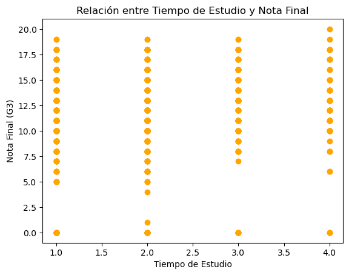

```python
plt.scatter(df_studen_consolidado_1['studytime'], df_studen_consolidado_1['G3'], color='orange')
plt.title('Relación entre Tiempo de Estudio y Nota Final')
plt.xlabel('Tiempo de Estudio')
plt.ylabel('Nota Final (G3)')
plt.show()
```

#### Gráfico de líneas

Analizar el rendimiento a lo largo del tiempo (G1, G2, G3) Objetivo: Visualizar cómo varían las calificaciones a lo largo del tiempo.

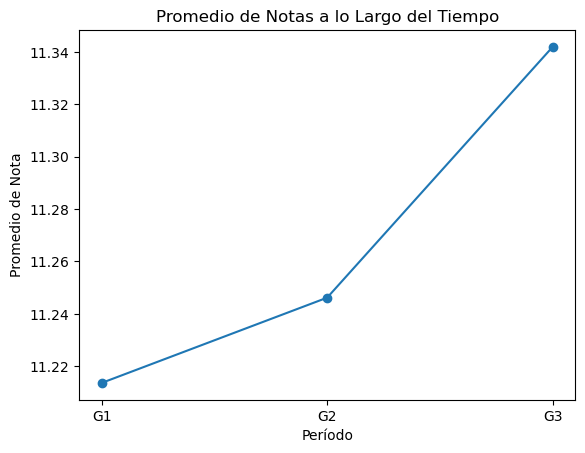

```python
plt.plot(df_studen_consolidado_1[['G1', 'G2', 'G3']].mean(), marker='o')
plt.title('Promedio de Notas a lo Largo del Tiempo')
plt.xlabel('Período')
plt.ylabel('Promedio de Nota')
plt.xticks(ticks=[0, 1, 2], labels=['G1', 'G2', 'G3'])
plt.show()
```

#### Histogramas

##### Distribución de las edades (age)

Objetivo: Visualizar la distribución de edades de los estudiantes con una curva de densidad.

En este gráfico, estamos observando la distribución de edades de los estudiantes en nuestro dataset. Las barras del histograma nos muestran la frecuencia con la que aparece cada edad, mientras que la línea KDE nos proporciona una representación suavizada de esa distribución.

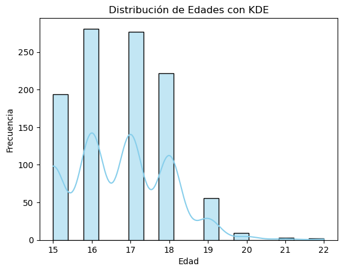

```python
sns.histplot(df_studen_consolidado_1['age'], kde=True, color='skyblue')
plt.title('Distribución de Edades con KDE')
plt.xlabel('Edad')
plt.ylabel('Frecuencia')
plt.show()
```

##### Distribución para el tiempo de estudio, los estudiantes que consumen alcohol diariamente y los estudiantes que consumen alcochol los fines de semana.

Objetivo: Visualizar los histogramas para varias columnas de manera simultánea.

En este gráfico, estamos observando los histogramas del tiempo de estudio, los estudiantes que consumen alcohol diariamente y los estudiantes que consumen alcochol los fines de semana en nuestro dataset. Las barras del histograma nos muestran la frecuencia con la que aparece cada variable.

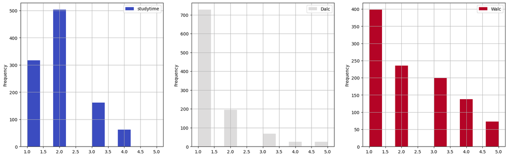

```python
new_df = df_studen_consolidado_1[['studytime', 'Dalc', 'Walc']]
new_df.plot(kind='hist', subplots=True, layout=(1,3), figsize=(20,6), grid=True, cmap='coolwarm')

plt.show()
```

#### Diagramas Circulares

Objetivo: Visualizar algunas columnas categóricas de nuestro dataset.

En estos gráficos, estamos observando los diagramas circulares para las siguentes columnas evaluando la frecuencia de cada subcategoría:

##### Sexo

Curso de portugués

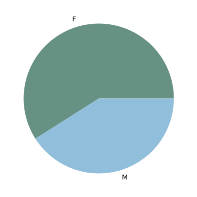

```python
sex_totals_por = df_student_por.groupby("sex")["sex"].value_counts()
color_list = ['#679183','#91BFDB']

sex_totals_por.plot(kind="pie", label="", figsize=(5,5), colors = color_list)
plt.show()
```

Curso de matemáticas

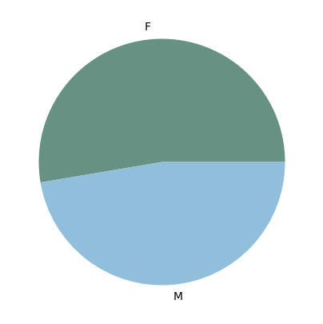

```python
sex_totals_mat = df_studen_mat.groupby("sex")["sex"].value_counts()

sex_totals_mat.plot(kind="pie", label="", figsize=(5,5), colors = color_list)
plt.show()
```

##### Estudiantes con acceso a internet

Curso de portugués

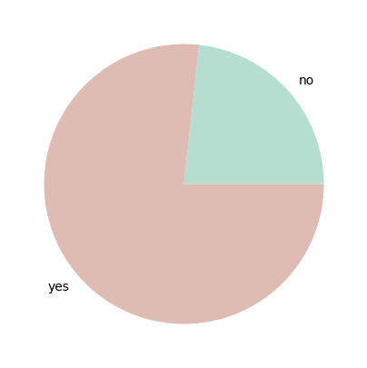

```python
internet_totals_por = df_student_por.groupby("internet")["internet"].value_counts()
color_list1 = ['#B4DED0', '#DEBCB4']

internet_totals_por.plot(kind="pie", label="", figsize=(5,5), colors = color_list1)
plt.show()
```

Curso de matemáticas

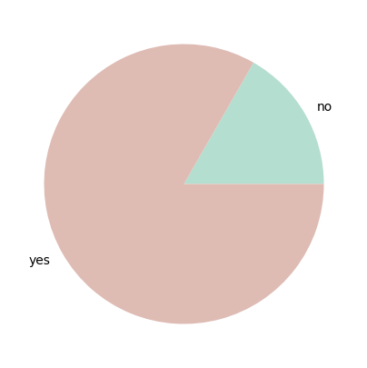

```python
internet_totals_mat = df_studen_mat.groupby("internet")["internet"].value_counts()
color_list1 = ['#B4DED0', '#DEBCB4']

internet_totals_mat.plot(kind="pie", label="", figsize=(5,5), colors = color_list1)
plt.show()
```

##### Estudiantes por asignatura

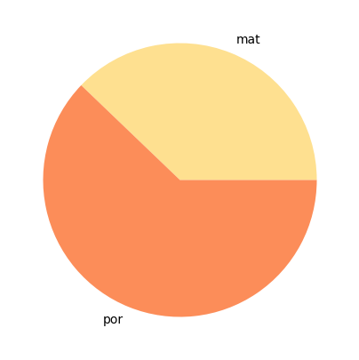

```python
asignature_totals = df_studen_consolidado_1.groupby("asignature")["asignature"].value_counts()
color_list2 = ['#FEE090', '#FC8D59']

asignature_totals.plot(kind="pie", label="", figsize=(5,5), colors = color_list2)
plt.show()
```

##### Razones por las que los estudiantes escogieron la escuela

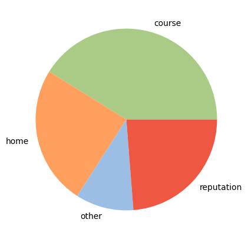

```python
reason_totals = df_studen_consolidado_1.groupby("reason")["reason"].value_counts()
color_list3 = ['#A9CB86', '#FF9F5E', '#9CBEE4', '#EE5741']

reason_totals.plot(kind="pie", label="", figsize=(5,5), colors = color_list3)
plt.show()
```

##### Clasificación de estudiantes por el tipo de trabajo de la madre

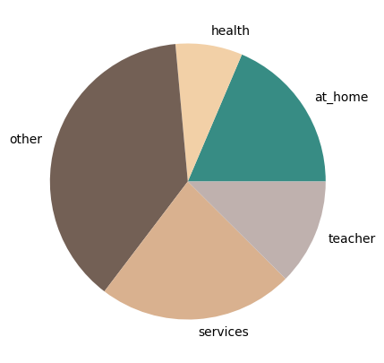

```python
Mjob_totals = df_studen_consolidado_1.groupby("Mjob")["Mjob"].value_counts()
color_list4 = ['#378C84', '#F2D0A7', '#736055', '#D9B18F', '#BFB1AE']

Mjob_totals.plot(kind="pie", label="", figsize=(5,5), colors = color_list4)
plt.show()
```

##### Clasificación del consumo de alcohol en estudiantes

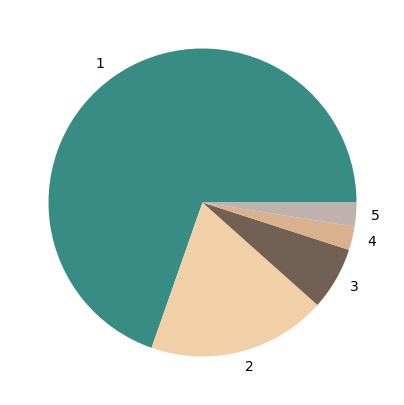

```python
Dalc_totals = df_studen_consolidado_1.groupby("Dalc")["Dalc"].value_counts()
color_list4 = ['#378C84', '#F2D0A7', '#736055', '#D9B18F', '#BFB1AE']

Dalc_totals.plot(kind="pie", label="", figsize=(5,5), colors = color_list4)
plt.show()
```

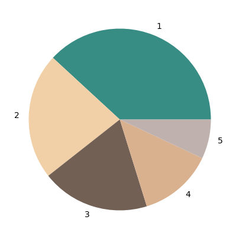

```python
Walc_totals = df_studen_consolidado_1.groupby("Walc")["Walc"].value_counts()
color_list4 = ['#378C84', '#F2D0A7', '#736055', '#D9B18F', '#BFB1AE']

Walc_totals.plot(kind="pie", label="", figsize=(5,5), colors = color_list4)
plt.show()
```

## Descripción de los datos

1. school - student's school (binary: 'GP' - Gabriel Pereira or 'MS' - Mousinho da Silveira)
2. sex - student's sex (binary: 'F' - female or 'M' - male)
3. age - student's age (numeric: from 15 to 22)
4. address - student's home address type (binary: 'U' - urban or 'R' - rural)
5. famsize - family size (binary: 'LE3' - less or equal to 3 or 'GT3' - greater than 3)
6. Pstatus - parent's cohabitation status (binary: 'T' - living together or 'A' - apart)
7. Medu - mother's education (numeric: 0 - none, 1 - primary education (4th grade), 2 – 5th to 9th grade, 3 – secondary education or 4 – higher education)
8. Fedu - father's education (numeric: 0 - none, 1 - primary education (4th grade), 2 – 5th to 9th grade, 3 – secondary education or 4 – higher education)
9. Mjob - mother's job (nominal: 'teacher', 'health' care related, civil 'services' (e.g. administrative or police), 'at_home' or 'other')
10. Fjob - father's job (nominal: 'teacher', 'health' care related, civil 'services' (e.g. administrative or police), 'at_home' or 'other')
11. reason - reason to choose this school (nominal: close to 'home', school 'reputation', 'course' preference or 'other')
12. guardian - student's guardian (nominal: 'mother', 'father' or 'other')
13. traveltime - home to school travel time (numeric: 1 - <15 min., 2 - 15 to 30 min., 3 - 30 min. to 1 hour, or 4 - >1 hour)
14. studytime - weekly study time (numeric: 1 - <2 hours, 2 - 2 to 5 hours, 3 - 5 to 10 hours, or 4 - >10 hours)
15. failures - number of past class failures (numeric: n if 1<=n<3, else 4)
16. schoolsup - extra educational support (binary: yes or no)
17. famsup - family educational support (binary: yes or no)
18. paid - extra paid classes within the course subject (Math or Portuguese) (binary: yes or no)
19. activities - extra-curricular activities (binary: yes or no)
20. nursery - attended nursery school (binary: yes or no)
21. higher - wants to take higher education (binary: yes or no)
22. internet - Internet access at home (binary: yes or no)
23. romantic - with a romantic relationship (binary: yes or no)
24. famrel - quality of family relationships (numeric: from 1 - very bad to 5 - excellent)
25. freetime - free time after school (numeric: from 1 - very low to 5 - very high)
26. goout - going out with friends (numeric: from 1 - very low to 5 - very high)
27. Dalc - workday alcohol consumption (numeric: from 1 - very low to 5 - very high)
28. Walc - weekend alcohol consumption (numeric: from 1 - very low to 5 - very high)
29. health - current health status (numeric: from 1 - very bad to 5 - very good)
30. absences - number of school absences (numeric: from 0 to 93)
31. These grades are related with the course subject, Math or Portuguese:
32. G1 - first period grade (numeric: from 0 to 20)
33. G2 - second period grade (numeric: from 0 to 20)
34. G3 - final grade (numeric: from 0 to 20, output target)

Additional note: there are several (382) students that belong to both datasets